# CyberTerrorism3 slides

## Predicting the Success of Cyber-Related Terrorist Attacks:

This dataset is from Global Terrorism Database curated by the University of Maryland:

National Consortium for the Study of Terrorism and Responses to Terrorism (START). (2018). Global Terrorism Database [Data file]. Retrieved from https://www.start.umd.edu/gtd.

It is a rich dataset with numerous variables and plenty of opportunities for analysis. In this project, we will focus on predicting the 'success' of attacks which are related to cyber-events or have consequences for cyber-infrastructure (we will describe these characteristics in further detail below.

To begin, we will take a look at how this study classifies a successful terrorist attack and distinguishes it from an unsuccessful attack. Below, is their description from pages 11 and 26 of their code-book (**[GTD Global Terrorism Database. Codebook: Inclusion Criteria and Variables](http://www.start.umd.edu/gtd/downloads/Codebook.pdf)**):

> "The GTD does not include plots or conspiracies that are not enacted, or at least attempted. For an event to be included in the GTD, the attackers must be “out the door,” en route to execute the attack. Planning, reconnaissance, and acquiring supplies do not meet this threshold. The GTD does include attacks that were attempted but ultimately unsuccessful. The circumstances vary depending on tactics (for details see the success variable, below). However, in general if a bomb is planted but fails to detonate; if an arsonist is intercepted by authorities before igniting a fire; or, if an assassin attempts and fails to kill his or her intended target, the attack is considered for inclusion in the GTD, and marked success=0." P. 11

> "Success of a terrorist strike is defined according to the tangible effects of the attack. Success is not judged in terms of the larger goals of the perpetrators. For example, a bomb that exploded in a building would be counted as a success even if it did not succeed in bringing the building down or inducing government repression. The definition of a successful attack depends on the type of attack. Essentially, the key question is whether or not the attack type took place. If a case has multiple attack types, it is successful if any of the attack types are successful, with the exception of assassinations, which are only successful if the intended target is killed. 1 = "Yes" The incident was successful. 0 = "No" The incident was not successful." P. 26

Thus, our focus below will be on using the data collected to build a model which will successfully predict the success of a terror attack. Below, we will begin importing and working with our data, and explanations and analysis will follow when pertinent.

### 1. Importing, Cleaning and General Overview:

#### A. Importing Data.

```python
df = pd.read_excel('globalterrorismdb_0718dist.xlsx',
                   usecols = 'A, I, K, M, S:W, AA:AB, AD, AJ, AL, AM, AN, AP, BG, BM:BN, BQ, CE, CG, DA',
                   dtype = {'summary':str, 'motive':str})
```

```python
# Went ahead and dropped some null values here since our kernel started to crash repeatedly:

print(cyber_data.shape)
cyber_data.dropna(axis = 0, how = 'any', inplace = True)
print(cyber_data.shape)
```

```
(181691, 24)
(116533, 24)
```

#### B. Selecting Rows Specific to Cyber-Related Terrorism:

In order to filter the dataset and focus our inquiry on cyber-related events, we will use the following regex statement. This statement attempts to focus on social-networks, email platforms as well as infrastructure (to a certain extent).

It should be note that this statement is susceptible to bias in a few ways. First of all, it is temporally biased in the sense that it includes Facebook and Twitter, while newer platforms or platforms in other countries might be prevalent. One way to reduce this bias would be to update the expression whenever possible with current data and considerations of standard practice and user habits.

```python
# Creating the input Dataframe (cyber_train):
# Using regex to isolate qualifying data and make a mask to filter our main dataframe:

import re

  # First taking a look to see how many rows that will give us to work with:

print(cyber_data.summary.str.contains('cyb+|social|inform+|network+|twit+|facebook|fake|electio+|internet|ads|adv+|priv+|hac+|breac+|emai+',
                         flags = re.IGNORECASE, regex = True).value_counts())

# Creating the mask:

mask = cyber_data.summary.str.contains(r'(cyb+|social|inform+|network+|twit+|facebook|fake|electio+|internet|ads|adv+|priv+|hac+|breac+|emai+)',
                           flags = re.IGNORECASE)

# Filtering our main data:

cyber_data = pd.DataFrame(cyber_data[mask])
```

```
False    109486
True       7047
Name: summary, dtype: int64
```

#### C. Splitting Our Train/Test Data:

Below, we dropped some specific columns in dataframe in order to make future processing more efficient. The 'event_id' column wasn't numerically significant and created problems when getting dummies was necessary. The same occured with 'summary' and 'motive.' These last two columns, however, will come in handy when considering avenues for further research, which we will discuss below.

```python
# Defining our Input and Output data:
# (Cleaning afterwards to prevent leakage)

X = cyber_data.drop(['event_id', 'success', 'summary', 'motive'], axis = 1)
Y = pd.DataFrame(cyber_data['success'])

X_train, X_test, Y_train, Y_test = train_test_split(X, Y, test_size = .25)

X_train_start_index = X_train.index
X_test_start_index = X_test.index
```

#### E. Applying Filters to Text Columns.

The cells below are an attempt to consolidate (or group) some of the values together with a few certain columns we will be focusing on. Given that these columns have a considerable number of unique values, when getting dummies later, it will greatly increase the size of our feature set. While an increased feature-set is not necessarily a bad thing, preventing the size from becoming too large will aid in our explanatory power later on. In other words, our feature set will have a comprehensible size, allowing us to explain the characteristics around a successful attack. Otherwise, we run the risk of a feature set which is too large for a human to understand and too many features - making it difficult to see which columns/characteristics are significant for our analysis.

Below, we focus mainly on the types of weapons, the named terrorist groups and the cities attacked. We also consolidated some of the sub_targets into larger groups. After running our preliminary models, we found that targets and sub_targets were significant to our models, so we conducted some further feature engineering afterwards, which we will discuss later.

There were a number of resources which were helpful in this grouping process, which we will lay out here:

Regarding the 'weapontxt' column, which describes the type of weapons used in the attack, and the 'sub_target' column (which provides further details on the primary target) we mainly referred to the codebook accompanying the study (as mentioned above: (**[GTD Global Terrorism Database. Codebook: Inclusion Criteria and Variables](http://www.start.umd.edu/gtd/downloads/Codebook.pdf)**)). The grouping below was rather simple - primarily placing a few types of weapon-groups and sub-targets together when it would not negatively impact our explanatory capabilites down the road.

The 'city' and 'group_name' columns were more technical and involved some outside research. The groupings below are aimed at linking cities together if they fall within an ideological, religious, environmental or political umbrella in which certain terrorist groups are interested. For example, some middle-eastern cities are considered to lean more 'Sunni' as opposed to 'Shia', while others are 'split.' Some South American cities lie within an area experiencing heavy gang activity (such as the Northern Triangle between Mexico and Panama). Our goal with these groupings was to combine cities whenever they had a common interest factor for terrorist events, in the hopes that it would consolidate their correlation and aid in our predictive models.

These groupings, however, can be improved upon with further in-depth research. Our time with this project was somewhat limited and there are a handful of regions we were unable to group together or research. Additionally, our expertise in global terrorism is slight in comparison to those working in the field, which would benefit from an expert team member when creating these filters. That said, it would be highly interesting to continue improving these classifications, especially given the wealth of information and databases made available by respected international research organizations, which we will list here:

Some cities and groups were classified according to their religious leanings:

- Some Middle-Eastern cities were grouped under a Sunni/Shia or Sunni/Shia Split category. These resources were helpful in ascertaining where a city fell with respect to these religious tendencies:
- A New York Times article by Sarah Almukhtar, Sergio Peçanha and Tim Wallace on January 5th, 2016, entitled: **[Behind Stark Political Divisions, a More Complex Map of Sunnis and Shiites.](https://www.nytimes.com/interactive/2016/01/04/world/middleeast/sunni-shiite-map-middle-east-iran-saudi-arabia.html)**
- A blog post by Olivier Ypsilantis on August 14th, 2014, entitled: **[Carte religieuse de l’Iran et ses voisins](http://zakhor-online.com/?attachment_id=7932)**.
- Max Fisher wrote a great article for Vox on March 26th, 2015 which has a lot of great maps for reference: **[40 maps that explain the Middle East](https://www.vox.com/a/maps-explain-the-middle-east)** The Gulf 2000 Project has a plethora of maps and resources regarding issues in the Middle-East, and specifically this page by Dr. Michael Izady entitled **[Atlas of the Islamic World and Vicinity (Infographs, Maps and Statistics Collection).](http://gulf2000.columbia.edu/maps.shtml)** Some other maps we used from this site were: - **[A map of West Africa](http://gulf2000.columbia.edu/images/maps/West_Africa_Religion_lg.png)**
  - **[A map of Libya](http://gulf2000.columbia.edu/images/maps/Libya_Religion_Western_Sector_lg.png)**
  - **[A Shia territories map](http://gulf2000.columbia.edu/images/maps/ShiasReligionCore_lg.png)**

The Crisis Group also has a number of useful resources and articles regarding these topics. Specifically regarding Colombia and South America, we referenced and article entitled **[Colombia’s Armed Groups Battle for the Spoils of Peace](https://www.crisisgroup.org/latin-america-caribbean/andes/colombia/63-colombias-armed-groups-battle-spoils-peace)** from Report 63 / Latin America & Caribbean 19 OCTOBER 2017. There was an interesting map by Mike Shand (International Crisis Group 2017), entitled **[Map of Armed Groups and Coca Crops in Colombia, 2017.](https://www.crisisgroup.org/latin-america-caribbean/andes/colombia/63-colombias-armed-groups-battle-spoils-peace#map-5700-8)**.

We'll also take this opportunity to list out further databases and resources we used for this project:

For 'group*names' we referenced START's resources again (as they have a wealth of resources surrounding the database we used and the elements it describes. Here, they list the names of **['Big, Allied and Dangerous' terrorist groups,](http://www.start.umd.edu/baad/database)*** which we used as the basis for a majority of our classification.

The **[SATP website](http://www.satp.org/conflict-maps/bangladesh)** was instrumental in gaining insight into Asian conflicts. Within this website, we referenced a specific article regarding the **[Nepalise Maoist conflicts](http://www.satp.org/terrorist-profile/nepal/communist-party-of-nepal-maoist)**, which described their objectives, operating areas, leaders, etc. Towards the bottom of the page, it includes a ranking by the Nepalese Home Ministry, of areas in Nepal according to their sensitivity to these issues. We then used this **[map](https://reliefweb.int/map/nepal/nepal-regions-zones-and-districts-cities-april-2015)** from ReliefWeb to help us locate smaller cities in pertinent areas.

South America and the Northern Triangle:

Again, there are a number of databases and materials available from top-level international organizations. Regarding the Northern Triangle (namely Guatemala, Honduras, El Salvador) we referenced the following articles:

- **[Central America’s Violent Northern Triangle](https://www.cfr.org/backgrounder/central-americas-violent-northern-triangle)**By Rocio Cara Labrador and Danielle Renwick (updated June 26th, 2018)
- The Insight Crime Organiztion has a main page for each country involved in frequent conflicts**[such as this one regarding El Salvador](https://www.insightcrime.org/el-salvador-organized-crime-news/)**
- Relief Web also had a variety of resources we used here, specifically a **[main search page](https://reliefweb.int/country/slv)** for each country that leads to reports, infographics and the like.
- The **[Humanitarian Reponse Group](https://www.humanitarianresponse.info/en/infographics)** also has great resources and infographics.
- The **[United Nations Regional Information Centre](https://www.unric.org/en/databases/26912-refugees-humanitarian-affairs-and-migration)** points to a number of outside resources depending on what one is looking for.
- In refrencing hotspots of violence in Guatemala, we used Relief Web's summary on **[Humanitarian Needs Overview for Guatemala in 2017](https://reliefweb.int/sites/reliefweb.int/files/resources/20180315_SUMMARY_HNO%20GT_ENG.pdf)**
- Regarding the same of El Salvador, we used Relief Web's **[Map of El Salvador.](https://reliefweb.int/sites/reliefweb.int/files/resources/20180405%20monthly%20humanitarian%20snapshot%20-%20ENG.pdf)**
- For Honduras we referred to an article entitled **['Northern Triangle is World's Extortion Hotspot'](https://www.insightcrime.org/news/brief/northern-triangle-world-extortion-hotspot/)** by Steven Dudley and Michael Lohmuller on JULY 1st, 2015. This article has a map that was helpful in locating our cities.
- Regarding Columbia, we frequently referred to the **[Crisis Group's resources.](https://www.crisisgroup.org/)** There were two articles in particular we referred to here. The first was entitled 'Colombia’s Armed Groups Battle for the Spoils of Peace' (which we already referenced above). The second was a map entitled **['Map of ELN Presence in Colombia in 2012 and 2018, and Expansion between 2012 and 2018'](https://www.crisisgroup.org/latin-america-caribbean/andes/colombia/68-missing-peace-colombias-new-government-and-last-guerrillas#map-6189-1)** within an article named **['The Missing Peace: Colombia’s New Government and Last Guerrillas'](https://www.crisisgroup.org/latin-america-caribbean/andes/colombia/68-missing-peace-colombias-new-government-and-last-guerrillas)** from their Report 68 / Latin America & Caribbean on July 12th, 2018.

Other General References include:

- **[Homeland Security Digital Library](https://www.hsdl.org/?collection&id=2167)**
- **[U Mass Lowell](https://www.uml.edu/Research/CTSS/Online-Resources.aspx)** Has a great page with links to further resources.
- The Council on Foreign Relations has a page entitled **[Invisible Armies Insurgency Tracker: A Visual History of Guerrilla Warfare From 1775 to 2012 (from April 18th, 2013](https://www.cfr.org/wars-and-warfare/invisible-armies-insurgency-tracker/p29917)**. As they describe it at the top of the page: "The interactive Invisible Armies Insurgency Tracker presents a database of insurgencies from 1775 to 2012. It supplements the comprehensive historical narrative in Invisible Armies: An Epic History of Guerrilla Warfare from Ancient Times to the Present, by CFR Senior Fellow Max Boot."
- West Point has **[The Combating Terrorism Center](https://ctc.usma.edu/regions/middle-east/)** which is incredibly helpful and insightful with their background information.
- **[The Terrorism Research and Analysis Consortium](https://www.trackingterrorism.org/region/afghanistan)** has a lot of information - mostly private and paid, but one can at least browse the surface of what they offer (we also used some of their 'vulnerable cities' classifications in our cells below).

##### Weapontxt:

###### Training Input:

```python
# Grouping Biological and Chemical Weapons:
cyber_train_X['weapontxt'] = cyber_train_X['weapontxt'].replace('Chemical', 'Bio-Chem')
cyber_train_X['weapontxt'] = cyber_train_X['weapontxt'].replace('Biological', 'Bio-Chem')

# Grouping Fake and Other together:
cyber_train_X['weapontxt'] = cyber_train_X['weapontxt'].replace('Fake Weapons', 'Fake/Other')
cyber_train_X['weapontxt'] = cyber_train_X['weapontxt'].replace('Other', 'Fake/Other')

# Aggregating Vehicle into Sabotage Equipment:
cyber_train_X['weapontxt'] = cyber_train_X['weapontxt'].replace(
    'Vehicle (not to include vehicle-borne explosives, i.e., car or truck bombs)', 'Sabotage Equipment')
```

##### Sub_targettxt:

###### Training Input:

```python
industrial = ['Gas/Oil/Electric', 'Industrial/Textiles/Factory', 'Farm/Ranch', 'Mining', 'Construction']
cyber_train_X['sub_targettxt'] = cyber_train_X['sub_targettxt'].where(
                                     cyber_train_X['sub_targettxt'].apply(lambda x: x not in industrial),
                                     other = 'Industrial')


white_collar = ['Restaurant/Bar/Café', 'Bank/Commerce', 'Multinational Corporation',
                'Medical/Pharmaceutical', 'Retail/Grocery/Bakery (including cell phone shops and generic shops)',
                'Hotel/Resort', 'Entertainment/Cultural/Stadium/Casino', 'Private Security Company/Firm',
                'Legal Services']
cyber_train_X['sub_targettxt'] = cyber_train_X['sub_targettxt'].where(
                                     cyber_train_X['sub_targettxt'].apply(lambda x: x not in white_collar),
                                     other = 'White_Collar')


gov_figure1 = ['Judges/Attorneys/Courts', 'Government Personnel (excluding police, military)']
cyber_train_X['sub_targettxt'] = cyber_train_X['sub_targettxt'].where(
                                     cyber_train_X['sub_targettxt'].apply(lambda x: x not in gov_figure1),
                                     other = 'Gov_Figure1')

gov_figure2 = ['Politician or Political Party Movement/Meeting/Rally', 'Royalty', 'Head of State',
               'Election-Related']
cyber_train_X['sub_targettxt'] = cyber_train_X['sub_targettxt'].where(
                                     cyber_train_X['sub_targettxt'].apply(lambda x: x not in gov_figure2),
                                     other = 'Gov_Figure2')


police_facilities = ['Police Buildings (Headquarters/Stations/School)',
                     'Police Patrol (including vehicles and convoys)',
                     'Police Checkpoint', 'Prison/Jail']
cyber_train_X['sub_targettxt'] = cyber_train_X['sub_targettxt'].where(
                                     cyber_train_X['sub_targettxt'].apply(lambda x: x not in gov_figure2),
                                     other = 'Police_Facilities')

military_facilities = ['Military Barracks/Base/Headquarters/Checkpost', 'Military Recruiting Station/Academy',
                       'Military Weaponry', 'Military Aircraft', 'Military Maritime',
                       'Military Transportation/Vehicle (excluding convoys)', 'Military Checkpoint',
                       'Paramilitary']
cyber_train_X['sub_targettxt'] = cyber_train_X['sub_targettxt'].where(
                                     cyber_train_X['sub_targettxt'].apply(lambda x: x not in military_facilities),
                                     other = 'Military_Facilities')


military_personnel = ['Military Unit/Patrol/Convoy', 'Non-combatant Personnel',
                      'Military Personnel (soldiers, troops, officers, forces)']
cyber_train_X['sub_targettxt'] = cyber_train_X['sub_targettxt'].where(
                                     cyber_train_X['sub_targettxt'].apply(lambda x: x not in military_personnel),
                                     other = 'Military_Personnel')


pilots_aircraft = ['Aircraft (not at an airport)', 'Airline Officer/Personnel']
cyber_train_X['sub_targettxt'] = cyber_train_X['sub_targettxt'].where(
                                     cyber_train_X['sub_targettxt'].apply(lambda x: x not in military_personnel),
                                     other = 'Pilots_Aircraft')

gov_diplomatic = [' Diplomatic Personnel (outside of embassy, consulate)', 'Embassy/Consulate',
                  'International Organization (peacekeeper, aid agency, compound)']
cyber_train_X['sub_targettxt'] = cyber_train_X['sub_targettxt'].where(
                                     cyber_train_X['sub_targettxt'].apply(lambda x: x not in gov_diplomatic),
                                     other = 'Gov_Diplomatic')

educational = ['Teacher/Professor/Instructor', 'School/University/Educational Building',
               'Other Personnel']
cyber_train_X['sub_targettxt'] = cyber_train_X['sub_targettxt'].where(
                                     cyber_train_X['sub_targettxt'].apply(lambda x: x not in educational),
                                     other = 'Educational')

food_water = ['Food Supply', 'Water Supply']
cyber_train_X['sub_targettxt'] = cyber_train_X['sub_targettxt'].where(
                                     cyber_train_X['sub_targettxt'].apply(lambda x: x not in food_water),
                                     other = 'Food_Water')

media = ['Newspaper Journalist/Staff/Facility', 'Radio Journalist/Staff/Facility',
         'Television Journalist/Staff/Facility', 'Other (including online news agencies)']
cyber_train_X['sub_targettxt'] = cyber_train_X['sub_targettxt'].where(
                                     cyber_train_X['sub_targettxt'].apply(lambda x: x not in media),
                                     other = 'Media')


religious = ['Religion Identified', 'Religious Figure', 'Place of Worship',
             'Affiliated Institution']
cyber_train_X['sub_targettxt'] = cyber_train_X['sub_targettxt'].where(
                                     cyber_train_X['sub_targettxt'].apply(lambda x: x not in military_personnel),
                                     other = 'Pilots_Aircraft')


political = ['Protrainer', 'Political Party Member/Rally', 'Party Official/Candidate/Other Personnel',
             'Party Office/Facility', 'Rally']
cyber_train_X['sub_targettxt'] = cyber_train_X['sub_targettxt'].where(
                                     cyber_train_X['sub_targettxt'].apply(lambda x: x not in political),
                                     other = 'Political')

mass_socio = ['Refugee (including Camps/IDP/Asylum Seekers)', 'Named Civilian', 'Student',
              'Race/Ethnicity Identified', 'Farmer', 'Vehicles/Transportation', 'Marketplace/Plaza/Square', 'Village/City/Town/Suburb',
              'House/Apartment/Residence', 'Laborer (General)/Occupation Identified', 'Procession/Gathering (funeral, wedding, birthday, religious)',
              'Public Areas (e.g., Public garden, parking lot, garage, beach, public buildings, camps)',
             'Memorial/Cemetery/Monument', 'Museum/Cultural Center/Cultural House', 'Labor Union Related',
              'Tourism Travel Agency', 'Tour Bus/Van/Vehicle', 'Tourist', 'Other Facility', 'train/train Tracks/ Trolley', 'Bus Station/Stop', 'Subway',
              'Bridge/Car Tunnel', 'Highway/Road/Toll/Traffic Signal', 'Taxi/Rickshaw']
cyber_train_X['sub_targettxt'] = cyber_train_X['sub_targettxt'].where(
                                     cyber_train_X['sub_targettxt'].apply(lambda x: x not in mass_socio),
                                     other = 'Mass_Social')



util_telecom = ['Radio', 'Television', 'Telephone/Telegraph', 'Internet Infrastructure',
                'Multiple Telecommunication Targets', 'Gas', 'Electricity', 'Oil']
cyber_train_X['sub_targettxt'] = cyber_train_X['sub_targettxt'].where(
                                     cyber_train_X['sub_targettxt'].apply(lambda x: x not in util_telecom),
                                     other = 'Util_Telecom')
```

##### Group_name:

Trying Group_name a bit and grouping them by ideology.

###### Training Input:

```python
# Separatists, Leftists and Rightists:

# Palestinian Separatists:
cyber_train_X['group_name'] = cyber_train_X['group_name'].replace('Hamas (Islamic Resistance Movement)',
                                                        'Palestinian_Separatists')
cyber_train_X['group_name'] = cyber_train_X['group_name'].replace('Palestinian Islamic Jihad (PIJ)',
                                                        'Palestinian_Separatists')
cyber_train_X['group_name'] = cyber_train_X['group_name'].replace('Popular Front for the Liberation of Palestine (PFLP)',
                                                        'Palestinian_Separatists')
cyber_train_X['group_name'] = cyber_train_X['group_name'].replace('Popular Resistance Committees',
                                                        'Palestinian_Separatists')
cyber_train_X['group_name'] = cyber_train_X['group_name'].replace('Al-Fatah',
                                                        'Palestinian_Separatists')

# Militants:
cyber_train_X['group_name'] = cyber_train_X['group_name'].replace('Militants',
                                                        'Militant_Gunmen_Groups')
cyber_train_X['group_name'] = cyber_train_X['group_name'].replace('Gunmen',
                                                        'Militant_Gunmen_Groups')
```

```python
# Irish Separatists
cyber_train_X['group_name'] = cyber_train_X['group_name'].replace('Real Irish Republican Army (RIRA)',
                                                        'Irish_Separatists')
cyber_train_X['group_name'] = cyber_train_X['group_name'].replace('Oglaigh Na Heireann',
                                                        'Irish_Separatists')
cyber_train_X['group_name'] = cyber_train_X['group_name'].replace('Irish Republican Army (IRA)',
                                                        'rish_Separatists')
```

```python
# Farc left and right
cyber_train_X['group_name'] = cyber_train_X['group_name'].replace('National Liberation Army of Colombia (ELN)',
                                                        'FARC_Leftist')
cyber_train_X['group_name'] = cyber_train_X['group_name'].replace('Popular Liberation Army (EPL)',
                                                        'FARC_Leftist')
cyber_train_X['group_name'] = cyber_train_X['group_name'].replace('Revolutionary Armed Forces of Colombia (FARC)',
                                                        'FARC_Leftist')

cyber_train_X['group_name'] = cyber_train_X['group_name'].replace('United Self Defense Units of Colombia (AUC)',
                                                        'FARC_Rightist')
```

##### City: Trying City Names by Religion, Tribal Associations or Conflict Areas:

###### Training Input:

```python
sunni_cities = ['Mosul', 'Kirkuk', 'Sanandaj', 'Ramadi', 'Trabzone', 'Diarbekir',
                'Damascus', 'Gwadar', 'Zahedan', 'Kandahar', 'Khiva', 'Fallujah',
                'Dakhla', 'Tajura', 'Sabrata', 'Azizia', 'Kasabat', 'Misrata', 'Tripoli',
                'Takrit', 'Tikrit']
cyber_train_X['city'] = cyber_train_X['city'].where(cyber_train_X['city'].apply(
                                lambda x: x not in sunni_cities), other = 'Sunni_Cities')
```

```python
shia_cities = ['Mecca', 'Najaf', 'Karbala', 'Samarra', 'Ahwaz', 'Basra',
               'Medina', 'Tabriz', 'Tunceli', 'Zahran', 'Tehran', 'Rasht', 'Bojnurd',
               'Hillah', 'Diwania', 'Khalis', 'Dujali', 'Balad', 'Khanaqin',
               'Sargodha', 'Dadu', 'Moro']
cyber_train_X['city'] = cyber_train_X['city'].where(cyber_train_X['city'].apply(
                                lambda x: x not in shia_cities), other = 'Shia_Cities')
```

```python
split_cities = ['Kirmanshah', 'Baghdad', 'Kadhimia', 'Kuwait', 'Kars', 'Maras',
               'Ankara', 'Sivas', 'Aleppo', 'Beirut', 'Abha', 'Jizan', 'Qazvin',
               'Gunbad', 'Ashgabat', 'Mashhad', 'Herat', 'Merv', 'Charju', 'Bukhara',
               'Samarkand', 'Mazari Sharif', 'Kandahar', 'Lar', 'Bandar Abbas', 'Dubai',
               'Abu Dhabi', 'Tashkent', 'Erzurum', 'Konya', 'Izmir', 'Bursa', 'Istanbul',
               'Tarhuna', ]
cyber_train_X['city'] = cyber_train_X['city'].where(cyber_train_X['city'].apply(
                                lambda x: x not in split_cities), other = 'Sunni_Shia_Split')
```

```python
# Nepal Maoist Conflict - Class A According to SATP
Nepal_maoist_A = ['Musikot', 'Rukumkot', 'Jajarkot District', 'Salyan', 'Pyuthan', 'Gajul', 'Rank', 'Budagaun',
                  'Kalikot District', 'Rolpa', 'Rolpa District', 'Rukum District', 'Khalanga']
cyber_train_X['city'] = cyber_train_X['city'].where(cyber_train_X['city'].apply(
                                lambda x: x not in Nepal_maoist_A), other = 'Nepal_maoist_A')
```

### 2. Preliminary Visualizations and Exploration:

Here we take a look at some of the correlations and relationships between our features/columns and see what we might want to focus on with our models.

#### A. Correlation:

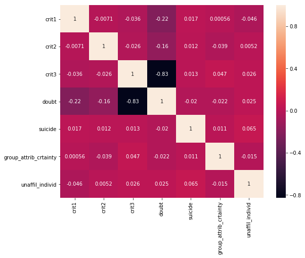

```python
f, ax = plt.subplots(figsize = (9, 7))
sns.heatmap(cyber_train_X.corr(), annot = True)
plt.show()
```

#### B. Most Active Groups:

```python
# Most prolific groups:

actives = cyber_train_X['group_name'].value_counts().head(10).drop('Unknown')
mask3 = cyber_train_X['group_name'].map(lambda x: x in actives)
actives_df = cyber_train_X[mask3]

temp_output = cyber_train_Y.loc[actives_df.index]

beta = actives.keys()
gamma = actives.values
```

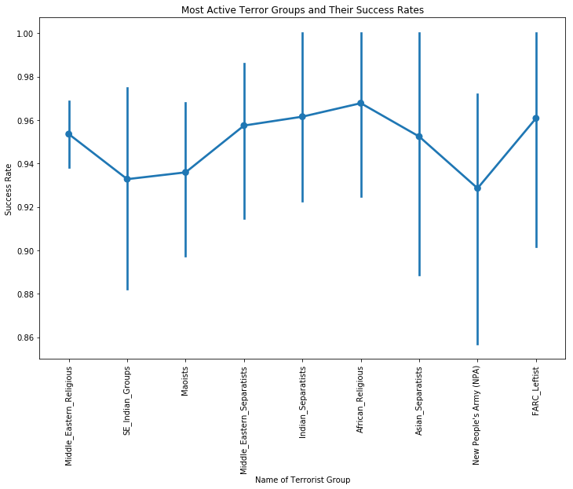

```python
f, ax = plt.subplots(figsize = (12, 8))
sns.pointplot(x = actives_df['group_name'], y = temp_output.success)
ax.set_xticklabels(labels = beta, rotation = '90')
ax.set_xlabel('Name of Terrorist Group')
ax.set_ylabel('Success Rate')
ax.set_title('Most Active Terror Groups and Their Success Rates')
plt.show()
```

#### C. Countries with Most Activity:

```python
# Hot-Spots:

hot_countries = cyber_train_X['country_txt'].value_counts().head(10)
mask3 = cyber_train_X['country_txt'].map(lambda x: x in hot_countries)
hot_countries_df = cyber_train_X[mask3]
phi = hot_countries_df['country_txt'].value_counts().head(10)

temp_output2 = cyber_train_Y.loc[hot_countries_df.index]


beta = phi.keys()
gamma = phi.values
```

[figure not shown]

```python
f, ax = plt.subplots(figsize = (12, 8))
sns.pointplot(x = beta, y = gamma)
ax.set_xticklabels(labels = beta, rotation = '90')
ax.set_xlabel('Name of Country')
ax.set_ylabel('Success Rate')
ax.set_title('Countries with Most Activity and Attack Success Rates')
plt.show()
```

### 3. Feature Selection:

Getting closer to modeling and using feature selection algorithms to see what will help us best minimize our feature set while maintaining the most amount of variation in our data.

We mainly focused on Select KBest within sklearn and PCA analysis to give us two perspectives on the data (one that we can parse out as humans, namely Select KBest, and one that is mostly computationally described, namely PCA).

#### A. Select K-Best:

##### Assessing the Overall DataFrame and its Features:

```python
# Getting dummies on our training and test sets (slight wrangling involved):
  # First dropping any na's:
cyber_train_X.dropna(axis = 0, inplace = True)
cyber_test_X.dropna(axis = 0, inplace = True)

  # Then grabbing an index to make sure we maintain our train/test split:
train_index = cyber_train_X.index
test_index = cyber_test_X.index

  # Dummy-time (we combined the dataframes here to make sure we didn't get duplicated dummies in both
    # training and test sets):
dummy_prep = pd.concat([cyber_train_X, cyber_test_X]).drop(['group_name', 'city', 'weapontxt'], axis = 1)
dummy_1 = pd.get_dummies(dummy_prep)

  # Re-filtering our Training/Test Inputs:
cyber_train_dummy_X = dummy_1.loc[train_index]
cyber_test_dummy_X = dummy_1.loc[test_index]

  # Re-filtering our Training/Test Outputs:
cyber_train_dummy_Y = cyber_train_Y.loc[train_index]
cyber_test_dummy_Y = cyber_test_Y.loc[test_index]
```

```python
# Making sure we have the same sizes still:
print(cyber_train_dummy_X.shape)
print(cyber_test_dummy_X.shape)
```

```
(5285, 6945)
(1762, 6945)
```

```python
# Fitting SelectKBest to our Features and output:
  # Here we tried a number of sizes: 20, 30, 500 and 700. We found that 25-30 got us the best results.
KBest_1 = feature_selection.SelectKBest(k = 25)
cyber_train_KBest1 = KBest_1.fit_transform(cyber_train_dummy_X, cyber_train_dummy_Y)

# Transforming the test-set
cyber_test_KBest1 = KBest_1.transform(cyber_test_dummy_X)
```

```python
# Creating a DF with the top 25 features:
feature_mask = KBest_1.get_support(indices = True)
KBest_1_features = pd.DataFrame(cyber_train_dummy_X.columns[feature_mask])

KBest_1_features
```

|  | 0 |
| --- | --- |
| 0 | doubt |
| 1 | country_txt_Ireland |
| 2 | country_txt_Nepal |
| 3 | attack_1txt_Assassination |
| 4 | attack_1txt_Bombing/Explosion |
| 5 | attack_1txt_Hostage Taking (Kidnapping) |
| 6 | target_1txt_Military |
| 7 | target_1txt_Private Citizens & Property |
| 8 | target_1txt_Unknown |
| 9 | sub_targettxt_Gov_Figure1 |
| 10 | sub_targettxt_Gov_Figure2 |
| 11 | sub_targettxt_Political |
| 12 | sub_targettxt_Unnamed Civilian/Unspecified |
| 13 | corp1_Election Commission of India |
| 14 | corp1_Not Applicable |
| 15 | corp1_Unified Communist Party of Nepal: Maoist... |
| 16 | specific_target_A police chief |
| 17 | specific_target_Candidate |
| 18 | specific_target_Polling Station |
| 19 | specific_target_Vehicle |
| 20 | victim_nationalitytxt_Ireland |
| 21 | victim_nationalitytxt_Nepal |
| 22 | sub_weapontxt_Letter Bomb |
| 23 | sub_weapontxt_Other Explosive Type |
| 24 | sub_weapontxt_Time Fuse |

##### Assessing Individual Features:

Running SelectKBest on a few features individually to see which of their values is selected as most important. This will help us consolidate some of those values and make a more specific dataframe.

###### Group_name:

```python
# Getting dummies on our training and test sets (slight wrangling involved):
names_train_X = cyber_train_X['group_name']
names_test_X = cyber_test_X['group_name']

names_train_index = cyber_train_X['group_name'].index
names_test_index = cyber_test_X['group_name'].index

names_dummy_prep = pd.concat([names_train_X, names_test_X])
names_dummy_1 = pd.get_dummies(names_dummy_prep)

# Filtering Training/Test Inputs:
names_train_dummy_X = names_dummy_1.loc[names_train_index]
names_test_dummy_X = names_dummy_1.loc[names_test_index]

# Filtering Training Outputs:
names_train_dummy_Y = cyber_train_Y.loc[names_train_index]
names_test_dummy_Y = cyber_test_Y.loc[names_test_index]
```

```python
# Fitting model to our features and output.
  # Again, we tried 30, 50 and 150, here. It seemed like 25-30 features gave us the best results.
KBest_names = feature_selection.SelectKBest(k = 25)
names_train_KBest = KBest_names.fit_transform(names_train_dummy_X, names_train_dummy_Y)

# Transforming our test set.
names_test_KBest = KBest_names.transform(names_test_dummy_X)
```

```python
# Summarizing the scores for those top 25 features in a df:

names_mask = KBest_names.get_support(indices = True)
KBest_names_features = pd.DataFrame(names_train_dummy_X.columns[names_mask])

KBest_names_features
```

|  | 0 |
| --- | --- |
| 0 | Armed Commandos of Liberation |
| 1 | Bangladesh Nationalist Party (BNP) |
| 2 | Besi Merah Putih Militia |
| 3 | Black Liberation Army |
| 4 | Communist Party of Nepal - Maoist (CPN-Maoist-... |
| 5 | Communist Party of Nepal-Maoist (Baidya) |
| 6 | Dima Halao Daoga (DHD) |
| 7 | Hekla Reception Committee-Initiative for More ... |
| 8 | Indian_Separatists |
| 9 | Informal Anarchist Federation |
| 10 | Jihadi-inspired extremists |
| 11 | Maoist Communist Party of Manipur |
| 12 | Maoists |
| 13 | Middle_Eastern_Religious |
| 14 | Muslim Brotherhood |
| 15 | National Socialist Council of Nagaland |
| 16 | Popular Resistance (Laiki Antistasi) |
| 17 | Pro Hartal Activists |
| 18 | Revolutionary Cells-Animal Liberation Brigade |
| 19 | Riyadus-Salikhin Reconnaissance and Sabotage B... |
| 20 | Salafi Abu-Bakr al-Siddiq Army |
| 21 | Tehrik-e-Nifaz-e-Aman Balochistan-Jhalawan Bri... |
| 22 | The World United Formosans for Independence (W... |
| 23 | Unknown |
| 24 | Zeliangrong United Front |

#### B. Principle Component Analysis:

##### Assessing the Overall DataFrame:

```python
from sklearn.decomposition import PCA

# Using the whole dataset (cyber_train_data):
PCA_1 = PCA(n_components = 25)  # Tried 30 and 500
cyber_train_PCA = PCA_1.fit_transform(cyber_train_dummy_X)
cyber_test_PCA = PCA_1.transform(cyber_test_dummy_X)
```

##### Assessing Individual Features

###### Group_name:

```python
# Now looking at group_name values:
PCA_name = PCA(n_components = 25) # Tried 30 and 150
name_train_PCA = PCA_name.fit_transform(names_train_dummy_X)
name_test_PCA = PCA_name.transform(names_test_dummy_X)
```

#### C. Creating Specified DF with Selected Features:

##### DataFrame from KBest Algorithms:

```python
# Training:
alpha = pd.DataFrame(cyber_train_KBest1, columns = KBest_1_features[0])
beta = pd.DataFrame(names_train_KBest, columns = KBest_names_features[0])
gamma = pd.DataFrame(city_train_KBest, columns = KBest_city_features[0])
delta = pd.DataFrame(weapon_train_KBest, columns = KBest_weapon_features[0])

KBest_train_X = pd.concat([alpha, beta, gamma, delta], axis = 1)
```

##### DataFrame from PCA:

```python
# Training:
cyber_train_PCA = pd.DataFrame(cyber_train_PCA)
name_train_PCA = pd.DataFrame(name_train_PCA)
cities_train_PCA = pd.DataFrame(cities_train_PCA)
weapon_train_PCA = pd.DataFrame(weapon_train_PCA)

PCA_train_X = pd.DataFrame()
PCA_train_X = pd.concat([cyber_train_PCA, name_train_PCA, cities_train_PCA, weapon_train_PCA], axis = 1)
```

### 4. Preliminary Models:

#### Logistic Regression:

##### KBest Features:

```python
from sklearn.linear_model import LogisticRegression
from sklearn.metrics import confusion_matrix, balanced_accuracy_score
from sklearn.model_selection import cross_val_score

KBest_logistic = LogisticRegression()

KBest_logistic = KBest_logistic.fit(KBest_train_X, cyber_train_dummy_Y)
KBest_logistic_train_pred_ = KBest_logistic.predict(KBest_train_X)
KBest_logistic_test_pred_ = KBest_logistic.predict(KBest_test_X)

# Evaluation:
  # Confustion Matrices:
KBest_logistic_confusion_train = confusion_matrix(cyber_train_dummy_Y, KBest_logistic_train_pred_, labels = [0, 1])
KBest_logistic_confusion_test = confusion_matrix(cyber_test_dummy_Y, KBest_logistic_test_pred_, labels = [0, 1])

  # Cross-validation and train/test scores:
KBest_logistic_cv = cross_val_score(KBest_logistic, KBest_train_X, cyber_train_dummy_Y, cv = 5)
KBest_logistic_train_score = KBest_logistic.score(KBest_train_X, cyber_train_dummy_Y)
KBest_logistic_test_score = KBest_logistic.score(KBest_test_X, cyber_test_dummy_Y)

  # Looking at balanced accuracy/f1 scores:
KBest_logistic_train = balanced_accuracy_score(cyber_train_dummy_Y, KBest_logistic_train_pred_)
KBest_logistic_test = balanced_accuracy_score(cyber_test_dummy_Y, KBest_logistic_test_pred_)
```

```python
plusminus = u"\u00B1"
print("\nThe mean cross-validation score is: {:.2%} {}{:.2%}".format(KBest_logistic_cv.mean(),
                                                                     plusminus, KBest_logistic_cv.std()))
print("The cv scores are: {}".format(KBest_logistic_cv))

conf_df = pd.DataFrame(KBest_logistic_confusion_train)

FP = conf_df.loc[0, 1]
FN = conf_df.loc[1, 0]
NegT = conf_df.iloc[0].sum()
PosT = conf_df.iloc[1].sum()

print("\nTraining-Set Metrics:")
print("The training score is: {:.2%}\n".format(KBest_logistic_train_score))
print(conf_df)
print('\nFalse Positive/Type I Error: {} ({:.2%})'.format(FP, (FP / NegT)))
print('False Negative/Type II Error: {} ({:.2%})'.format(FN, (FN / PosT)))
print('Balanced Accuracy: {:.2%}\n'.format(KBest_logistic_train))

conf_df2 = pd.DataFrame(KBest_logistic_confusion_test)

FP2 = conf_df2.loc[0, 1]
FN2 = conf_df2.loc[1, 0]
NegT2 = conf_df2.iloc[0].sum()
PosT2 = conf_df2.iloc[1].sum()

print("Test-Set Metrics:")
print("The test score is: {:.2%}\n".format(KBest_logistic_test_score))
print(conf_df2)
print('\nFalse Positive/Type I Error: {} ({:.2%})'.format(FP2, (FP2 / NegT2)))
print('False Negative/Type II Error: {} ({:.2%})'.format(FN2, (FN2 / PosT2)))
print('Balanced Accuracy: {:.2%}'.format(KBest_logistic_test))
```

```
The mean cross-validation score is: 94.12% ±0.22%
The cv scores are: [0.94512772 0.94039735 0.9385052  0.94134342 0.94039735]

Training-Set Metrics:
The training score is: 94.30%

     0     1
0  195   260
1   41  4789

False Positive/Type I Error: 260 (57.14%)
False Negative/Type II Error: 41 (0.85%)
Balanced Accuracy: 71.00%

Test-Set Metrics:
The test score is: 93.53%

    0     1
0  61    92
1  22  1587

False Positive/Type I Error: 92 (60.13%)
False Negative/Type II Error: 22 (1.37%)
Balanced Accuracy: 69.25%
```

##### PCA Features:

```python
PCA_logistic = LogisticRegression()

PCA_logistic = PCA_logistic.fit(PCA_train_X, cyber_train_dummy_Y)
PCA_logistic_train_pred_ = PCA_logistic.predict(PCA_train_X)
PCA_logistic_test_pred_ = PCA_logistic.predict(PCA_test_X)

# Evaluation:
  # Confustion Matrices:
PCA_logistic_confusion_train = confusion_matrix(cyber_train_dummy_Y, PCA_logistic_train_pred_, labels = [0, 1])
PCA_logistic_confusion_test = confusion_matrix(cyber_test_dummy_Y, PCA_logistic_test_pred_, labels = [0, 1])

  # Cross-validation and train/test scores:
PCA_logistic_cv = cross_val_score(PCA_logistic, PCA_train_X, cyber_train_dummy_Y, cv = 5)
PCA_logistic_train_score = PCA_logistic.score(PCA_train_X, cyber_train_dummy_Y)
PCA_logistic_test_score = PCA_logistic.score(PCA_test_X, cyber_test_dummy_Y)

  # Looking at balanced accuracy/f1 scores:
PCA_logistic_train = balanced_accuracy_score(cyber_train_dummy_Y, PCA_logistic_train_pred_)
PCA_logistic_test = balanced_accuracy_score(cyber_test_dummy_Y, PCA_logistic_test_pred_)
```

```python
plusminus = u"\u00B1"
print("\nThe mean cross-validation score is: {:.2%} {}{:.2%}".format(PCA_logistic_cv.mean(),
                                                                     plusminus, PCA_logistic_cv.std()))
print("The cv scores are: {}".format(PCA_logistic_cv))

conf_df = pd.DataFrame(PCA_logistic_confusion_train)

FP = conf_df.loc[0, 1]
FN = conf_df.loc[1, 0]
NegT = conf_df.iloc[0].sum()
PosT = conf_df.iloc[1].sum()

print("\nTraining-Set Metrics:")
print("The training score is: {:.2%}\n".format(PCA_logistic_train_score))
print(conf_df)
print('\nFalse Positive/Type I Error: {} ({:.2%})'.format(FP, (FP / NegT)))
print('False Negative/Type II Error: {} ({:.2%})'.format(FN, (FN / PosT)))
print('Balanced Accuracy: {:.2%}\n'.format(PCA_logistic_train))

conf_df2 = pd.DataFrame(PCA_logistic_confusion_test)

FP2 = conf_df2.loc[0, 1]
FN2 = conf_df2.loc[1, 0]
NegT2 = conf_df2.iloc[0].sum()
PosT2 = conf_df2.iloc[1].sum()

print("Test-Set Metrics:")
print("The test score is: {:.2%}\n".format(PCA_logistic_test_score))
print(conf_df2)
print('\nFalse Positive/Type I Error: {} ({:.2%})'.format(FP2, (FP2 / NegT2)))
print('False Negative/Type II Error: {} ({:.2%})'.format(FN2, (FN2 / PosT2)))
print('Balanced Accuracy: {:.2%}'.format(PCA_logistic_test))
```

```
The mean cross-validation score is: 93.26% ±0.35%
The cv scores are: [0.93566698 0.93377483 0.92904447 0.93661306 0.92809839]

Training-Set Metrics:
The training score is: 93.64%

     0     1
0  170   285
1   51  4779

False Positive/Type I Error: 285 (62.64%)
False Negative/Type II Error: 51 (1.06%)
Balanced Accuracy: 68.15%

Test-Set Metrics:
The test score is: 92.96%

    0     1
0  55    98
1  26  1583

False Positive/Type I Error: 98 (64.05%)
False Negative/Type II Error: 26 (1.62%)
Balanced Accuracy: 67.17%
```

#### Support Vector Classifier:

##### KBest Features:

```python
from sklearn.svm import SVC

KBest_SVC = SVC()

KBest_SVC = KBest_SVC.fit(KBest_train_X, cyber_train_dummy_Y)
KBest_SVC_train_pred_ = KBest_SVC.predict(KBest_train_X)
KBest_SVC_test_pred_ = KBest_SVC.predict(KBest_test_X)

# Evaluation:
  # Confusion matrices:
KBest_SVC_confusion_train = confusion_matrix(cyber_train_dummy_Y, KBest_SVC_train_pred_, labels = [0, 1])
KBest_SVC_confusion_test = confusion_matrix(cyber_test_dummy_Y, KBest_SVC_test_pred_, labels = [0, 1])

  # Cross-validation and train/test scores:
KBest_SVC_cv = cross_val_score(KBest_SVC, KBest_train_X, cyber_train_dummy_Y, cv = 5)
KBest_SVC_train_score = KBest_SVC.score(KBest_train_X, cyber_train_dummy_Y)
KBest_SVC_test_score = KBest_SVC.score(KBest_test_X, cyber_test_dummy_Y)

  # Looking at balanced accuracy/f1 scores:
KBest_SVC_train = balanced_accuracy_score(cyber_train_dummy_Y, KBest_SVC_train_pred_)
KBest_SVC_test = balanced_accuracy_score(cyber_test_dummy_Y, KBest_SVC_test_pred_)
```

```python
plusminus = u"\u00B1"
print("\nThe mean cross-validation score is: {:.2%} {}{:.2%}".format(KBest_SVC_cv.mean(),
                                                                     plusminus, KBest_SVC_cv.std()))
print("The cv scores are: {}".format(KBest_SVC_cv))

conf_df = pd.DataFrame(KBest_SVC_confusion_train)

FP = conf_df.loc[0, 1]
FN = conf_df.loc[1, 0]
NegT = conf_df.iloc[0].sum()
PosT = conf_df.iloc[1].sum()

print("\nTraining-Set Metrics:")
print("The training score is: {:.2%}\n".format(KBest_SVC_train_score))
print(conf_df)
print('\nFalse Positive/Type I Error: {} ({:.2%})'.format(FP, (FP / NegT)))
print('False Negative/Type II Error: {} ({:.2%})'.format(FN, (FN / PosT)))
print('Balanced Accuracy: {:.2%}\n'.format(KBest_SVC_train))

conf_df2 = pd.DataFrame(KBest_SVC_confusion_test)

FP2 = conf_df2.loc[0, 1]
FN2 = conf_df2.loc[1, 0]
NegT2 = conf_df2.iloc[0].sum()
PosT2 = conf_df2.iloc[1].sum()

print("Test-Set Metrics:")
print("The test score is: {:.2%}\n".format(KBest_SVC_test_score))
print(conf_df2)
print('\nFalse Positive/Type I Error: {} ({:.2%})'.format(FP2, (FP2 / NegT2)))
print('False Negative/Type II Error: {} ({:.2%})'.format(FN2, (FN2 / PosT2)))
print('Balanced Accuracy: {:.2%}'.format(KBest_SVC_test))
```

```
The mean cross-validation score is: 93.64% ±0.35%
The cv scores are: [0.9422895  0.93472091 0.93282876 0.9385052  0.93377483]

Training-Set Metrics:
The training score is: 93.76%

     0     1
0  172   283
1   47  4783

False Positive/Type I Error: 283 (62.20%)
False Negative/Type II Error: 47 (0.97%)
Balanced Accuracy: 68.41%

Test-Set Metrics:
The test score is: 93.59%

    0     1
0  61    92
1  21  1588

False Positive/Type I Error: 92 (60.13%)
False Negative/Type II Error: 21 (1.31%)
Balanced Accuracy: 69.28%
```

##### PCA Features

```python
PCA_SVC = SVC()

PCA_SVC = PCA_SVC.fit(PCA_train_X, cyber_train_dummy_Y)
PCA_SVC_train_pred_ = PCA_SVC.predict(PCA_train_X)
PCA_SVC_test_pred_ = PCA_SVC.predict(PCA_test_X)

# Evaluation:
  # Confusion Matrices:
PCA_SVC_confusion_train = confusion_matrix(cyber_train_dummy_Y, PCA_SVC_train_pred_, labels = [0, 1])
PCA_SVC_confusion_test = confusion_matrix(cyber_test_dummy_Y, PCA_SVC_test_pred_, labels = [0, 1])

  # Cross-validation and train/test scores:
PCA_SVC_cv = cross_val_score(PCA_SVC, PCA_train_X, cyber_train_dummy_Y, cv = 5)
PCA_SVC_train_score = PCA_SVC.score(PCA_train_X, cyber_train_dummy_Y)
PCA_SVC_test_score = PCA_SVC.score(PCA_test_X, cyber_test_dummy_Y)

  # Looking at the F1/balanced accuracy scores:
PCA_SVC_train = balanced_accuracy_score(cyber_train_dummy_Y, PCA_SVC_train_pred_)
PCA_SVC_test = balanced_accuracy_score(cyber_test_dummy_Y, PCA_SVC_test_pred_)
```

```python
plusminus = u"\u00B1"
print("\nThe mean cross-validation score is: {:.2%} {}{:.2%}".format(PCA_SVC_cv.mean(),
                                                                     plusminus, PCA_SVC_cv.std()))
print("The cv scores are: {}".format(PCA_SVC_cv))

conf_df = pd.DataFrame(PCA_SVC_confusion_train)

FP = conf_df.loc[0, 1]
FN = conf_df.loc[1, 0]
NegT = conf_df.iloc[0].sum()
PosT = conf_df.iloc[1].sum()

print("\nTraining-Set Metrics:")
print("The training score is: {:.2%}\n".format(PCA_SVC_train_score))
print(conf_df)
print('\nFalse Positive/Type I Error: {} ({:.2%})'.format(FP, (FP / NegT)))
print('False Negative/Type II Error: {} ({:.2%})'.format(FN, (FN / PosT)))
print('Balanced Accuracy: {:.2%}\n'.format(PCA_SVC_train))

conf_df2 = pd.DataFrame(PCA_SVC_confusion_test)

FP2 = conf_df2.loc[0, 1]
FN2 = conf_df2.loc[1, 0]
NegT2 = conf_df2.iloc[0].sum()
PosT2 = conf_df2.iloc[1].sum()

print("Test-Set Metrics:")
print("The test score is: {:.2%}\n".format(PCA_SVC_test_score))
print(conf_df2)
print('\nFalse Positive/Type I Error: {} ({:.2%})'.format(FP2, (FP2 / NegT2)))
print('False Negative/Type II Error: {} ({:.2%})'.format(FN2, (FN2 / PosT2)))
print('Balanced Accuracy: {:.2%}'.format(PCA_SVC_test))
```

```
The mean cross-validation score is: 93.72% ±0.33%
The cv scores are: [0.94134342 0.9385052  0.93282876 0.93945128 0.93377483]

Training-Set Metrics:
The training score is: 93.72%

     0     1
0  171   284
1   48  4782

False Positive/Type I Error: 284 (62.42%)
False Negative/Type II Error: 48 (0.99%)
Balanced Accuracy: 68.29%

Test-Set Metrics:
The test score is: 93.59%

    0     1
0  61    92
1  21  1588

False Positive/Type I Error: 92 (60.13%)
False Negative/Type II Error: 21 (1.31%)
Balanced Accuracy: 69.28%
```

#### Gradient Boosting:

##### KBest Features:

```python
from sklearn.ensemble import GradientBoostingClassifier

KBest_GBC = GradientBoostingClassifier()

KBest_GBC = KBest_GBC.fit(KBest_train_X, cyber_train_dummy_Y)
KBest_GBC_train_pred_ = KBest_GBC.predict(KBest_train_X)
KBest_GBC_test_pred_ = KBest_GBC.predict(KBest_test_X)

# Evaluation:
  # Confusion matrices:
KBest_GBC_confusion_train = confusion_matrix(cyber_train_dummy_Y, KBest_GBC_train_pred_, labels = [0, 1])
KBest_GBC_confusion_test = confusion_matrix(cyber_test_dummy_Y, KBest_GBC_test_pred_, labels = [0, 1])

  # Cross-validation and train/test scores:
KBest_GBC_cv = cross_val_score(KBest_GBC, KBest_train_X, cyber_train_dummy_Y, cv = 5)
KBest_GBC_train_score = KBest_GBC.score(KBest_train_X, cyber_train_dummy_Y)
KBest_GBC_test_score = KBest_GBC.score(KBest_test_X, cyber_test_dummy_Y)

  # Looking at the F1/balanced-accuracy scores:
KBest_GBC_train = balanced_accuracy_score(cyber_train_dummy_Y, KBest_GBC_train_pred_)
KBest_GBC_test = balanced_accuracy_score(cyber_test_dummy_Y, KBest_GBC_test_pred_)
```

```python
plusminus = u"\u00B1"
print("\nThe mean cross-validation score is: {:.2%} {}{:.2%}".format(KBest_GBC_cv.mean(),
                                                                     plusminus, KBest_GBC_cv.std()))
print("The cv scores are: {}".format(KBest_GBC_cv))

conf_df = pd.DataFrame(KBest_GBC_confusion_train)

FP = conf_df.loc[0, 1]
FN = conf_df.loc[1, 0]
NegT = conf_df.iloc[0].sum()
PosT = conf_df.iloc[1].sum()

print("\nTraining-Set Metrics:")
print("The training score is: {:.2%}\n".format(KBest_GBC_train_score))
print(conf_df)
print('\nFalse Positive/Type I Error: {} ({:.2%})'.format(FP, (FP / NegT)))
print('False Negative/Type II Error: {} ({:.2%})'.format(FN, (FN / PosT)))
print('Balanced Accuracy: {:.2%}\n'.format(KBest_GBC_train))

conf_df2 = pd.DataFrame(KBest_GBC_confusion_test)

FP2 = conf_df2.loc[0, 1]
FN2 = conf_df2.loc[1, 0]
NegT2 = conf_df2.iloc[0].sum()
PosT2 = conf_df2.iloc[1].sum()

print("Test-Set Metrics:")
print("The test score is: {:.2%}\n".format(KBest_GBC_test_score))
print(conf_df2)
print('\nFalse Positive/Type I Error: {} ({:.2%})'.format(FP2, (FP2 / NegT2)))
print('False Negative/Type II Error: {} ({:.2%})'.format(FN2, (FN2 / PosT2)))
print('Balanced Accuracy: {:.2%}'.format(KBest_GBC_test))

print('\n\nFeature Importances:\n')
feat_imp = pd.DataFrame(KBest_GBC.feature_importances_.round(2), index = KBest_train_X.columns,
                        columns = ["Importances"])
display(feat_imp.sort_values('Importances', ascending = False))
```

```
The mean cross-validation score is: 94.19% ±0.23%
The cv scores are: [0.94512772 0.93945128 0.94039735 0.94418165 0.94039735]

Training-Set Metrics:
The training score is: 94.97%

     0     1
0  236   219
1   47  4783

False Positive/Type I Error: 219 (48.13%)
False Negative/Type II Error: 47 (0.97%)
Balanced Accuracy: 75.45%

Test-Set Metrics:
The test score is: 93.59%

    0     1
0  67    86
1  27  1582

False Positive/Type I Error: 86 (56.21%)
False Negative/Type II Error: 27 (1.68%)
Balanced Accuracy: 71.06%


Feature Importances:
```

| 0 | Importances |
| --- | --- |
| attack_1txt_Assassination | 0.31 |
| target_1txt_Military | 0.20 |
| Explosives | 0.16 |
| corp1_Election Commission of India | 0.04 |
| corp1_Unified Communist Party of Nepal: Maoist (UCPN-M) | 0.02 |
| country_txt_Ireland | 0.02 |
| sub_weapontxt_Letter Bomb | 0.02 |
| Unknown | 0.02 |
| Gilgit | 0.01 |
| specific_target_Candidate | 0.01 |
| sub_weapontxt_Time Fuse | 0.01 |
| Hekla Reception Committee-Initiative for More Social Eruptions | 0.01 |
| Faizabad | 0.01 |
| Thoubal | 0.01 |
| Smile | 0.01 |
| Chukitong | 0.01 |
| Tral | 0.01 |
| Middle_Eastern_Religious | 0.01 |
| Pagadian | 0.01 |
| Aguada | 0.01 |
| target_1txt_Private Citizens & Property | 0.01 |
| attack_1txt_Hostage Taking (Kidnapping) | 0.01 |
| attack_1txt_Bombing/Explosion | 0.01 |
| Imphal | 0.01 |
| Belauri | 0.00 |
| Belbari | 0.00 |
| Dublin | 0.00 |
| Baharak district | 0.00 |
| Zeliangrong United Front | 0.00 |
| doubt | 0.00 |
| Paris | 0.00 |
| Thouda Bhabok Leikai | 0.00 |
| Tibu | 0.00 |
| Tehrik-e-Nifaz-e-Aman Balochistan-Jhalawan Brigade (TNAB-Jhalawan Brigade) | 0.00 |
| Tigzirt | 0.00 |
| Tirap district | 0.00 |
| Tissa | 0.00 |
| Tuensang district | 0.00 |
| Tunga | 0.00 |
| Waghaz district | 0.00 |
| Yairipok | 0.00 |
| Zab | 0.00 |
| Zhutovi | 0.00 |
| Incendiary | 0.00 |
| The World United Formosans for Independence (WUFI) | 0.00 |
| Muslim Brotherhood | 0.00 |
| Salafi Abu-Bakr al-Siddiq Army | 0.00 |
| Riyadus-Salikhin Reconnaissance and Sabotage Battalion of Chechen Martyrs | 0.00 |
| country_txt_Nepal | 0.00 |
| target_1txt_Unknown | 0.00 |
| sub_targettxt_Gov_Figure1 | 0.00 |
| sub_targettxt_Gov_Figure2 | 0.00 |
| sub_targettxt_Political | 0.00 |
| sub_targettxt_Unnamed Civilian/Unspecified | 0.00 |
| corp1_Not Applicable | 0.00 |
| specific_target_A police chief | 0.00 |
| specific_target_Polling Station | 0.00 |
| specific_target_Vehicle | 0.00 |
| victim_nationalitytxt_Ireland | 0.00 |
| victim_nationalitytxt_Nepal | 0.00 |
| sub_weapontxt_Other Explosive Type | 0.00 |
| Armed Commandos of Liberation | 0.00 |
| Bangladesh Nationalist Party (BNP) | 0.00 |
| Besi Merah Putih Militia | 0.00 |
| Black Liberation Army | 0.00 |
| Communist Party of Nepal - Maoist (CPN-Maoist-Chand) | 0.00 |
| Communist Party of Nepal-Maoist (Baidya) | 0.00 |
| Dima Halao Daoga (DHD) | 0.00 |
| Indian_Separatists | 0.00 |
| Informal Anarchist Federation | 0.00 |
| Jihadi-inspired extremists | 0.00 |
| Maoist Communist Party of Manipur | 0.00 |
| Maoists | 0.00 |
| National Socialist Council of Nagaland | 0.00 |
| Popular Resistance (Laiki Antistasi) | 0.00 |
| Pro Hartal Activists | 0.00 |
| Revolutionary Cells-Animal Liberation Brigade | 0.00 |
| Melee | 0.00 |

##### PCA Features

```python
PCA_GBC = GradientBoostingClassifier()

PCA_GBC = PCA_GBC.fit(PCA_train_X, cyber_train_dummy_Y)
PCA_GBC_train_pred_ = PCA_GBC.predict(PCA_train_X)
PCA_GBC_test_pred_ = PCA_GBC.predict(PCA_test_X)

# Evaluation:

  # Confusion matrices:
PCA_GBC_confusion_train = confusion_matrix(cyber_train_dummy_Y, PCA_GBC_train_pred_, labels = [0, 1])
PCA_GBC_confusion_test = confusion_matrix(cyber_test_dummy_Y, PCA_GBC_test_pred_, labels = [0, 1])

  # Cross_validation and train/test score:
PCA_GBC_cv = cross_val_score(PCA_GBC, PCA_train_X, cyber_train_dummy_Y, cv = 5, scoring = 'f1')
PCA_GBC_train_score = PCA_GBC.score(PCA_train_X, cyber_train_dummy_Y)
PCA_GBC_test_score = PCA_GBC.score(PCA_test_X, cyber_test_dummy_Y)

  # Looking at the F1/balanced accuracy scores:
PCA_GBC_train = balanced_accuracy_score(cyber_train_dummy_Y, PCA_GBC_train_pred_)
PCA_GBC_test = balanced_accuracy_score(cyber_test_dummy_Y, PCA_GBC_test_pred_)
```

```python
plusminus = u"\u00B1"
print("\nThe mean cross-validation score is: {:.2%} {}{:.2%}".format(PCA_GBC_cv.mean(),
                                                                     plusminus, PCA_GBC_cv.std()))
print("The cv scores are: {}".format(PCA_GBC_cv))

conf_df = pd.DataFrame(PCA_GBC_confusion_train)

FP = conf_df.loc[0, 1]
FN = conf_df.loc[1, 0]
NegT = conf_df.iloc[0].sum()
PosT = conf_df.iloc[1].sum()

print("\nTraining-Set Metrics:")
print("The training score is: {:.2%}\n".format(PCA_GBC_train_score))
print(conf_df)
print('\nFalse Positive/Type I Error: {} ({:.2%})'.format(FP, (FP / NegT)))
print('False Negative/Type II Error: {} ({:.2%})'.format(FN, (FN / PosT)))
print('Balanced Accuracy: {:.2%}\n'.format(PCA_GBC_train))

conf_df2 = pd.DataFrame(PCA_GBC_confusion_test)

FP2 = conf_df2.loc[0, 1]
FN2 = conf_df2.loc[1, 0]
NegT2 = conf_df2.iloc[0].sum()
PosT2 = conf_df2.iloc[1].sum()

print("Test-Set Metrics:")
print("The test score is: {:.2%}\n".format(PCA_GBC_test_score))
print(conf_df2)
print('\nFalse Positive/Type I Error: {} ({:.2%})'.format(FP2, (FP2 / NegT2)))
print('False Negative/Type II Error: {} ({:.2%})'.format(FN2, (FN2 / PosT2)))
print('Balanced Accuracy: {:.2%}'.format(PCA_GBC_test))
```

```
The mean cross-validation score is: 96.44% ±0.25%
The cv scores are: [0.96247465 0.96068548 0.96708861 0.9645749  0.96708861]

Training-Set Metrics:
The training score is: 95.36%

     0     1
0  230   225
1   20  4810

False Positive/Type I Error: 225 (49.45%)
False Negative/Type II Error: 20 (0.41%)
Balanced Accuracy: 75.07%

Test-Set Metrics:
The test score is: 93.47%

    0     1
0  63    90
1  25  1584

False Positive/Type I Error: 90 (58.82%)
False Negative/Type II Error: 25 (1.55%)
Balanced Accuracy: 69.81%
```